# Tarea 4

09-12-2021

## Introducción

Lo invito a ver este tutoria donde aprenderemos a realizar paletas de colores y modificaciones de temas para un gráfico de de barras y utilizando un theme de ggplot2 realizado en la tarea 3.

Para este tutorial realizado en ioslides, se creo una imagen para el fondo en formato PNG en Adobe Illustration, esta presentacion esta realizado con texto de color negro y lo destacado en color azul, cuenta con gráficos en dos columnas con información relevante para este tutorial, notas del presentador.

Sin mas preambulos lo invito a deleitarse con este interactivo tutorial.

## Primera parte Creacion del Gráfico de barras por defecto

En una primera instancia crearemos un grafico por defecto de la base de datos “penguins” para luego realizar modificaciones, asignando el objeto con el nombre barras1.

Para crear el objeto asignando el nombre de barras1 <- y agregamos nuestro grafico modelo para este ejemplo. Quedando una funcón mas menos asi:

barras1 <- ggplot(penguins, aes(y = island, fill = species)) +

geom_bar() + labs(title = “Pingüinos en archipiélago de Palmer”, subtitle = “Número de pinguinos en cada isla”)

## barras1

Obteniendo lo siguiente:

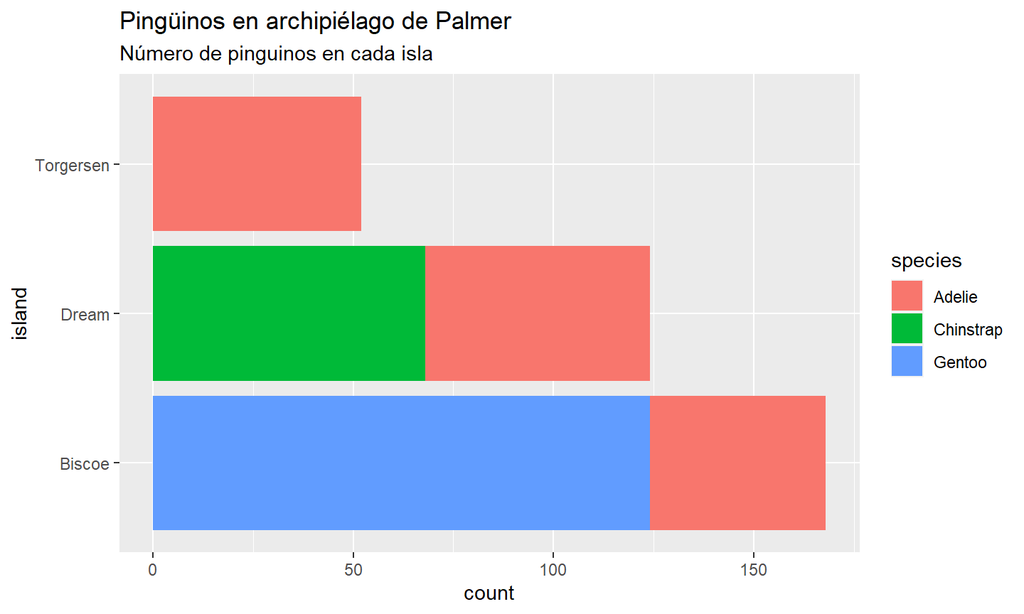

Mis Notas.

- En Torgersen solo hay Pinguinos de la especie Adelie
- En Dream hay pinguinos de la especie de Adelie y Chinstrap
- En Biscoe hay pinguinos de la especie Adelie y Gento
- La especie Adelie la podemos encontrar en todos las islas

## Segunda parte nuestra paleta de colores

Visitaremos el siguiente Link:

https://emilhvitfeldt.github.io/r-color-palettes/discrete.html

Crearemos nuestra paleta y la modificaremos!! sera genial

comenzaremos escogiendo nuestra paleta con con la función paletteer_d

Para este ejemplo utilizaremos la paleta “calecopal::fire”

```
## <colors>
## #B77B7BFF #FEEC44FF #F66C09FF #E60505FF #2C1B21FF
```

## Asignaremos como objeto nuestra paleta

Luego de eso asignaremos como paleta1 la paleta escogida para este tutorial de la siguiente manera:

paleta1 <- c(“#B77B7BFF”, “#FEEC44FF”, “#F66C09FF”, “#E60505FF”, “#2C1B21FF”)

Asignaremos el valor a lo que queremos modificar en el gráfico y asignaremos como fill1 al scale_fill_manual que contiene el valor de paleta1

fill1 <- scale_fill_manual(values = paleta1)

Para cambiar el color de nuestro gráfico aplicamos lo siguiente:

barras1 + scale_fill_manual(values = paleta1)

## y obtener asi el siguiente grafico

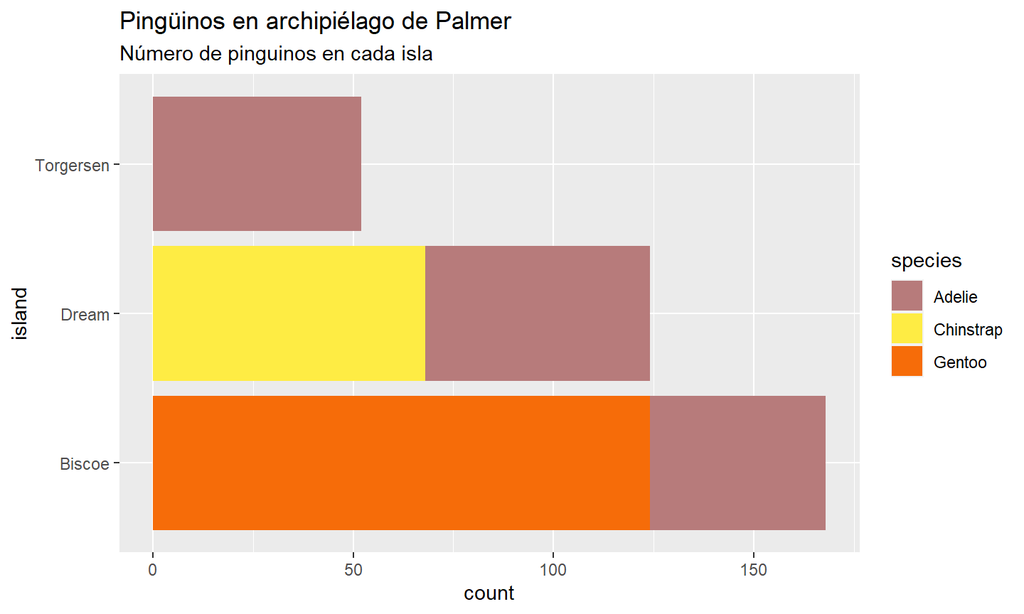

Puedes modificar tu grafico de barras solo cambiando los valores de las funciones descritas anteriormente.

## Tercera parte Modificación de thema y tamaño del texto

Ahora que tenemos nuestras barras listas seria bueno cambiar un poco el tamaño y color de los titulos y subtitulos, para eso utilizaremos la siguiente función, usted podra cambiar el tamaño cambiando el valor en la función “size” y el color en la función color

- plot.title = element_text(size = 30, color = “#2C1B21FF” )
- plot.subtitle = element_text(size = 15, color = “#E60505FF”)

## Gráfico barra 1 concambios incluidos

- Podemos notar el cambio en el tamaño del texto y y el color de las barras.
- Con estos simples cambios en las funciones podemos realizar estos cambios.
- Ahora es tu turno intentarlo.

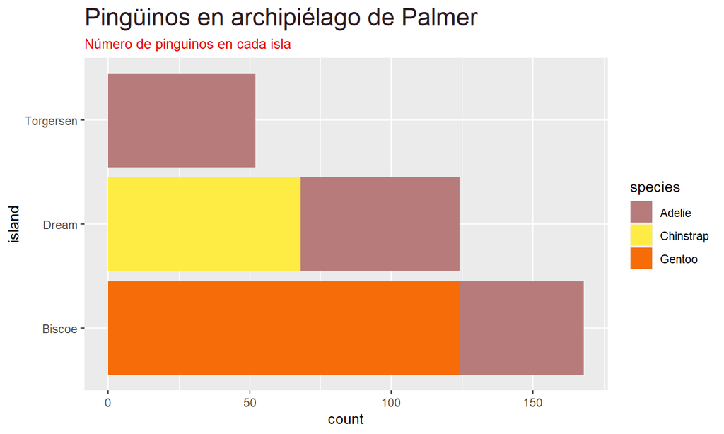